# CherAnalysis

# Load

Load all subjects

```r
bdata <- read_csv("../gambling_clean_data.csv", show_col_types = F)
```

Load the model assignments

```r
assignments <- read_csv("../LL_model2.csv", show_col_types = FALSE)
```

Double check we have the right data:

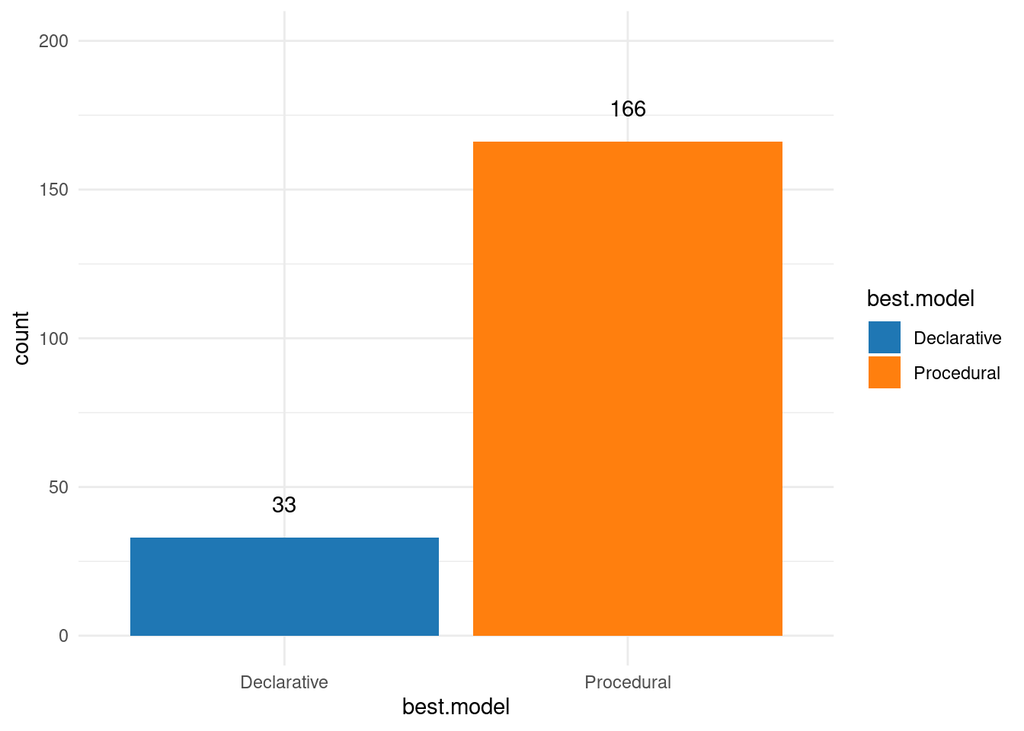

```r
ggplot(assignments, aes(x=best.model, fill=best.model)) +
  stat_count() +
  ylim(c(0, 200)) +
  stat_count(binwidth=1,
             geom="text",
             aes(label=..count..), vjust=-1.5) +
  scale_fill_d3() +
  theme_minimal()
```

## Parameter Differences Between the Two Groups

```r
assignments <- assignments %>%
  mutate(TempDiff = proc.temp - decl.temp) %>%
  mutate(LearnDiff = alpha + decay) %>%
  mutate(Procedural = if_else(best.model=="Procedural", 1, 0))
```

Now let’s plot the differences in temperatures across both groups:

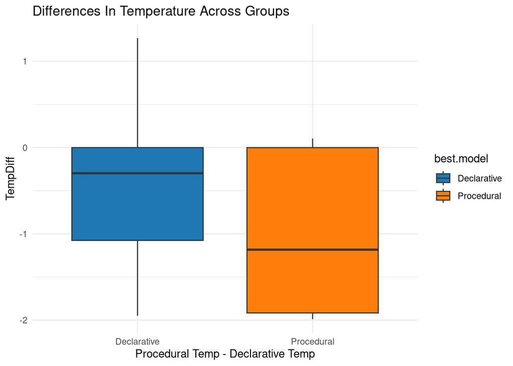

```r
ggplot(assignments, aes(x=best.model, y=TempDiff, fill=best.model)) +
  geom_boxplot() +
  theme_minimal() +
  ggtitle("Differences In Temperature Across Groups") +
  xlab("Procedural Temp - Declarative Temp") +
  scale_fill_d3()
```

A logistic model can successfully account for this:

```r
mod <- glm(Procedural ~ TempDiff,
           family="binomial",
           #weights=abs(diff.LL),
           data=assignments)

tab_model(mod)
```

|  | Procedural |  |  |
| --- | --- | --- | --- |
| Predictors | Odds Ratios | CI | p |
| (Intercept) | 2.98 | 1.90 – 4.84 | **<0.001** |
| TempDiff | 0.49 | 0.30 – 0.77 | **0.003** |
| Observations | 199 |  |  |
| R<sup>2</sup> Tjur | 0.050 |  |  |

as well as a t-test:

```r
t.test(TempDiff ~ best.model, assignments, paired=F) %>%
  tidy() %>%
  kable() %>%
  kable_styling(bootstrap_options=c("striped", "hover"))
```

| estimate | estimate1 | estimate2 | statistic | p.value | parameter | conf.low | conf.high | method | alternative |
| --- | --- | --- | --- | --- | --- | --- | --- | --- | --- |
| 0.5160327 | -0.4774846 | -0.9935173 | 3.235038 | 0.0022393 | 46.60832 | 0.1950615 | 0.837004 | Welch Two Sample t-test | two.sided |

It is difficult to conceptualize alpha vs. decay, but we can plot them:

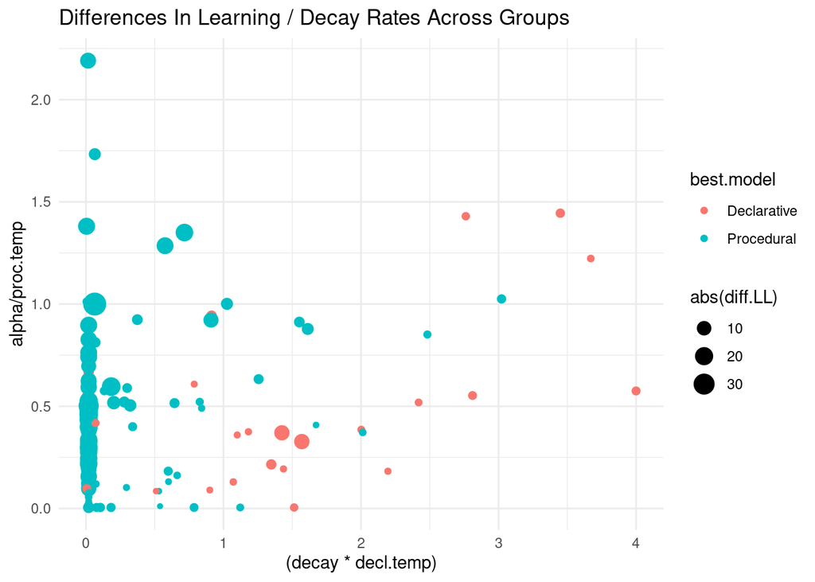

```r
ggplot(assignments, aes(x=(decay*decl.temp), y=alpha/proc.temp, col=best.model, size=abs(diff.LL))) +
  geom_point() +
  theme_minimal() +
  ggtitle("Differences In Learning / Decay Rates Across Groups") +
  scale_fill_d3()
```

# Behavioral Analysis

First we need to merge the behavioral and assignment data

```r
full <- full_join(bdata, assignments, by="HCPID")
```

# Group Differences in Response Switch

```r
bytrial <- full %>%
  group_by(HCPID, TrialType) %>%
  filter(!is.na(ResponseSwitch)) %>%
  summarise(ResponseSwitch = mean(ResponseSwitch),
            RT = mean(RT),
            Model=mlv(best.model),
            deltaLL = mean(diff.LL)) %>%
  mutate(TrialType = recode(TrialType, Reward = "Win", Punishment = "Loss", Neutral = "Neutral"))
```

And now, let’s visualize

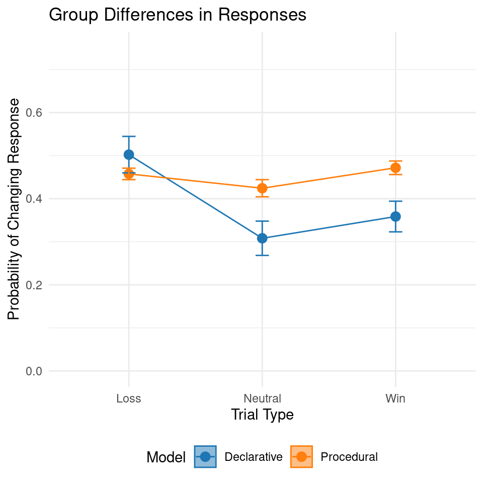

```r
ggplot(bytrial, aes(x=TrialType, y=ResponseSwitch, col=Model, fill=Model)) +
  stat_summary(geom="point", fun.data="mean_se", size=3) +
  stat_summary(geom="ribbon", fun.data = mean_se, alpha=0.5) +
  stat_summary(geom="errorbar", fun.data = mean_se, width=0.1) +
  stat_summary(geom="line", aes(group=Model), fun.data="mean_se") +
  coord_cartesian(ylim=c(0, .75)) +
  ylab("Probability of Changing Response") +
  xlab("Trial Type") +
  ggtitle("Group Differences in Responses") +
  scale_color_d3() +
  scale_fill_d3() +
  theme_minimal() +
  theme(legend.position = "bottom")
```

```r
ggsave("responseswitch.png", dpi=72)
```

The analysis reveal a main effect of Model (Group):

```r
mlm_feedback_I <- glmer(ResponseSwitch ~ best.model *  TrialType + (1|HCPID),
                         family="binomial",
                         weights=abs(diff.LL),
                         data=filter(full, !is.na(ResponseSwitch)))
mlm_feedback_IS <- glmer(ResponseSwitch ~ best.model *  TrialType + (1|HCPID) + (0 + TrialType|HCPID),
                         family="binomial",
                         weights=abs(diff.LL),
                         data=filter(full, !is.na(ResponseSwitch)))
anova(mlm_feedback_I, mlm_feedback_IS)
```

```
## Data: filter(full, !is.na(ResponseSwitch))
## Models:
## mlm_feedback_I: ResponseSwitch ~ best.model * TrialType + (1 | HCPID)
## mlm_feedback_IS: ResponseSwitch ~ best.model * TrialType + (1 | HCPID) + (0 + TrialType | HCPID)
##                 npar   AIC   BIC logLik deviance  Chisq Df Pr(>Chisq)
## mlm_feedback_I     7 81081 81132 -40533    81067
## mlm_feedback_IS   13 77437 77532 -38706    77411 3655.2  6  < 2.2e-16 ***
## ---
## Signif. codes:  0 '***' 0.001 '**' 0.01 '*' 0.05 '.' 0.1 ' ' 1
```

```r
mlm_feedback_IS %>%
  tidy() %>%
  kable() %>%
  kable_styling(bootstrap_options=c("striped", "hover"))
```

| effect | group | term | estimate | std.error | statistic | p.value |
| --- | --- | --- | --- | --- | --- | --- |
| fixed | NA | (Intercept) | -1.6001478 | 0.4018970 | -3.9814876 | 0.0000685 |
| fixed | NA | best.modelProcedural | 1.1047427 | 0.4273246 | 2.5852541 | 0.0097307 |
| fixed | NA | TrialTypePunishment | 1.4510659 | 0.3656174 | 3.9688098 | 0.0000722 |
| fixed | NA | TrialTypeReward | 0.3657193 | 0.3754884 | 0.9739828 | 0.3300651 |
| fixed | NA | best.modelProcedural:TrialTypePunishment | -1.1179088 | 0.3847858 | -2.9052753 | 0.0036693 |
| fixed | NA | best.modelProcedural:TrialTypeReward | -0.1277199 | 0.3954962 | -0.3229359 | 0.7467438 |
| ran_pars | HCPID | sd__(Intercept) | 0.9108228 | NA | NA | NA |
| ran_pars | HCPID.1 | sd__TrialTypeNeutral | 1.3719747 | NA | NA | NA |
| ran_pars | HCPID.1 | cor__TrialTypeNeutral.TrialTypePunishment | 0.3803546 | NA | NA | NA |
| ran_pars | HCPID.1 | cor__TrialTypeNeutral.TrialTypeReward | 0.3917938 | NA | NA | NA |
| ran_pars | HCPID.1 | sd__TrialTypePunishment | 0.4528264 | NA | NA | NA |
| ran_pars | HCPID.1 | cor__TrialTypePunishment.TrialTypeReward | -0.0567938 | NA | NA | NA |
| ran_pars | HCPID.1 | sd__TrialTypeReward | 0.8878867 | NA | NA | NA |

```r
tab_model(mlm_feedback_IS)
```

|  | ResponseSwitch |  |  |
| --- | --- | --- | --- |
| Predictors | Odds Ratios | CI | p |
| (Intercept) | 0.20 | 0.09 – 0.44 | **<0.001** |
| best model [Procedural] | 3.02 | 1.31 – 6.97 | **0.010** |
| TrialType [Punishment] | 4.27 | 2.08 – 8.74 | **<0.001** |
| TrialType [Reward] | 1.44 | 0.69 – 3.01 | 0.330 |
| best model [Procedural] × TrialType [Punishment] | 0.33 | 0.15 – 0.70 | **0.004** |
| best model [Procedural] × TrialType [Reward] | 0.88 | 0.41 – 1.91 | 0.747 |
| Random Effects |  |  |  |
| σ<sup>2</sup> | 3.29 |  |  |
| τ<sub>00</sub> <sub>HCPID</sub> | 0.83 |  |  |
| τ<sub>11</sub> <sub>HCPID.TrialTypeNeutral</sub> | 1.88 |  |  |
| τ<sub>11</sub> <sub>HCPID.TrialTypePunishment</sub> | 0.21 |  |  |
| τ<sub>11</sub> <sub>HCPID.TrialTypeReward</sub> | 0.79 |  |  |
| ρ<sub>01</sub> |  |  |  |
| ρ<sub>01</sub> |  |  |  |
| ICC | 0.20 |  |  |
| N <sub>HCPID</sub> | 199 |  |  |
| Observations | 10927 |  |  |
| Marginal R<sup>2</sup> / Conditional R<sup>2</sup> | 0.025 / 0.221 |  |  |

# Group Differences in Persistance

Now, let’s look at the data by block:

```r
byblock <- full %>%
  group_by(HCPID, BlockTypeCoded) %>%
  summarise(Persistance = mean(ConsecSameResp),
            MaxPersistance = max(ConsecSameResp),
            RT = mean(RT),
            Model=mlv(best.model),
            deltaLL = mean(diff.LL)) %>%
  rename(Block = BlockTypeCoded) %>%
  mutate(Block = recode(Block, MostlyReward = "Mostly Wins", MostlyPunishment = "Mostly Losses"))
```

This is a visualization of the mean persistance by block and model.

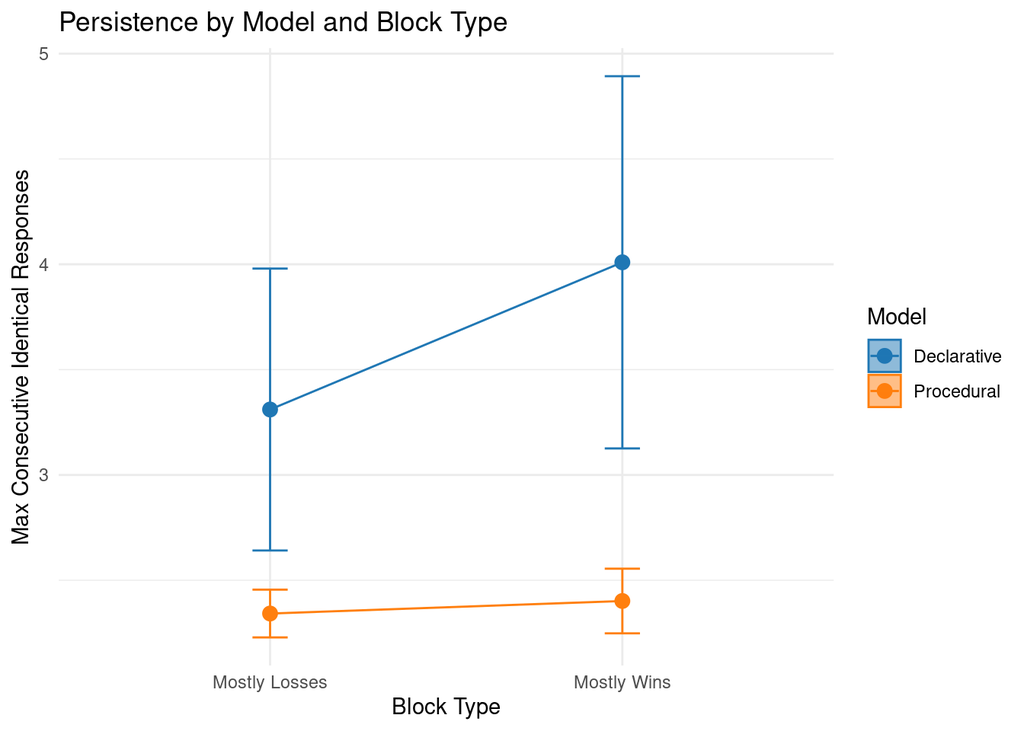

```r
ggplot(byblock, aes(x=Block, y=Persistance, col=Model, fill=Model)) +
  stat_summary(geom="point", fun.data="mean_se", size=3) +
  stat_summary(geom="ribbon", fun.data = "mean_se", alpha=0.5) +
  stat_summary(geom="errorbar", fun.data = "mean_se", width=0.1) +
  stat_summary(geom="line", aes(group=Model), fun.data="mean_se") +
  xlab("Block Type") +
  ylab("Max Consecutive Identical Responses") +
  ggtitle("Persistence by Model and Block Type") +
  scale_color_d3() +
  scale_fill_d3() +
  theme_minimal()
```

```r
ggsave("persistance.png", dpi=72)
```

To analyze this, we will use generalized linear model with a Poisson distribution. The choice of a Poisson distribution is given by the fact that the distribution of longest consecutive streaks (persistance) should obey a Poisson. Just in case, here is the actual distribution.

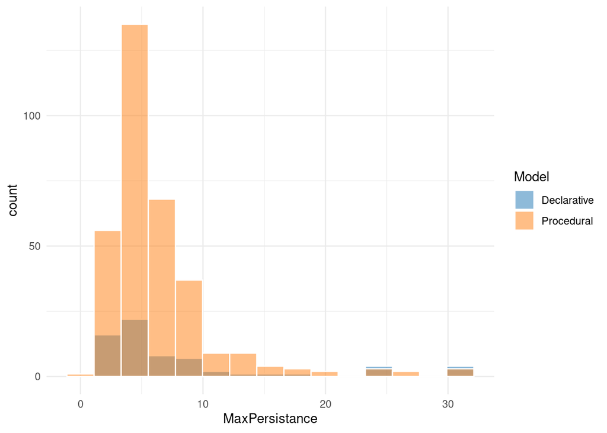

```r
ggplot(byblock, aes(x=MaxPersistance, fill=Model)) +
  geom_histogram(col="white", alpha=0.5, position = "identity", bins=15) +
  scale_fill_d3() +
  theme_minimal()
```

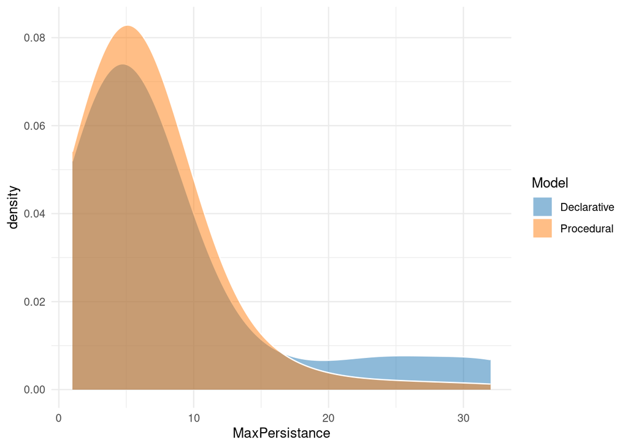

```r
ggplot(byblock, aes(x=MaxPersistance, fill=Model)) +
  geom_density(col="white", alpha=0.5, position = "identity", bw=4) +
  scale_fill_d3() +
  theme_minimal()
```

We first fit a Poisson model

```r
mod1 <- glmer(MaxPersistance ~ Model * Block + (1|HCPID),
              family="poisson",
              weights=abs(byblock$deltaLL),
              data=byblock)

mod1 %>%
  tidy() %>%
  kable() %>%
  kable_styling(bootstrap_options=c("striped", "hover"))
```

| effect | group | term | estimate | std.error | statistic | p.value |
| --- | --- | --- | --- | --- | --- | --- |
| fixed | NA | (Intercept) | 1.8133849 | 0.1115486 | 16.256463 | 0.0000000 |
| fixed | NA | ModelProcedural | -0.1329077 | 0.1201340 | -1.106329 | 0.2685842 |
| fixed | NA | BlockMostly Wins | 0.2496215 | 0.0448901 | 5.560719 | 0.0000000 |
| fixed | NA | ModelProcedural:BlockMostly Wins | -0.1316991 | 0.0473779 | -2.779758 | 0.0054399 |
| ran_pars | HCPID | sd__(Intercept) | 0.5113426 | NA | NA | NA |

```r
tab_model(mod1)
```

|  | MaxPersistance |  |  |
| --- | --- | --- | --- |
| Predictors | Incidence Rate Ratios | CI | p |
| (Intercept) | 6.13 | 4.93 – 7.63 | **<0.001** |
| Model [Procedural] | 0.88 | 0.69 – 1.11 | 0.269 |
| Block [Mostly Wins] | 1.28 | 1.18 – 1.40 | **<0.001** |
| Model [Procedural] × Block [Mostly Wins] | 0.88 | 0.80 – 0.96 | **0.005** |
| Random Effects |  |  |  |
| σ<sup>2</sup> | 0.16 |  |  |
| τ<sub>00</sub> <sub>HCPID</sub> | 0.26 |  |  |
| ICC | 0.62 |  |  |
| N <sub>HCPID</sub> | 199 |  |  |
| Observations | 398 |  |  |
| Marginal R<sup>2</sup> / Conditional R<sup>2</sup> | 0.026 / 0.634 |  |  |

It is possible to conceptualize the Max Persistance count as a Negative binomial

```r
mod2 <- MASS::glm.nb(MaxPersistance ~ Model * Block,
                     weights=abs(byblock$deltaLL),
                     data=byblock)

mod2 %>%
  tidy() %>%
  kable() %>%
  kable_styling(bootstrap_options=c("striped", "hover"))
```

| term | estimate | std.error | statistic | p.value |
| --- | --- | --- | --- | --- |
| (Intercept) | 2.6417441 | 0.0784503 | 33.674129 | 0.0000000 |
| ModelProcedural | -0.7057085 | 0.0808819 | -8.725168 | 0.0000000 |
| BlockMostly Wins | 0.2496201 | 0.1098072 | 2.273258 | 0.0230107 |
| ModelProcedural:BlockMostly Wins | -0.1316967 | 0.1132208 | -1.163184 | 0.2447547 |

```r
tab_model(mod2)
```

|  | MaxPersistance |  |  |
| --- | --- | --- | --- |
| Predictors | Incidence Rate Ratios | CI | p |
| (Intercept) | 14.04 | 12.07 – 16.41 | **<0.001** |
| Model [Procedural] | 0.49 | 0.42 – 0.58 | **<0.001** |
| Block [Mostly Wins] | 1.28 | 1.03 – 1.59 | **0.023** |
| Model [Procedural] × Block [Mostly Wins] | 0.88 | 0.70 – 1.09 | 0.245 |
| Observations | 398 |  |  |
| R<sup>2</sup> Nagelkerke | 0.455 |  |  |

```r
gf <- goodfit(byblock$MaxPersistance, type= "nbinomial",method= "ML")
summary(gf)
```

```
##
##   Goodness-of-fit test for nbinomial distribution
##
##                       X^2 df     P(> X^2)
## Likelihood Ratio 333.9576 20 8.914914e-59
```

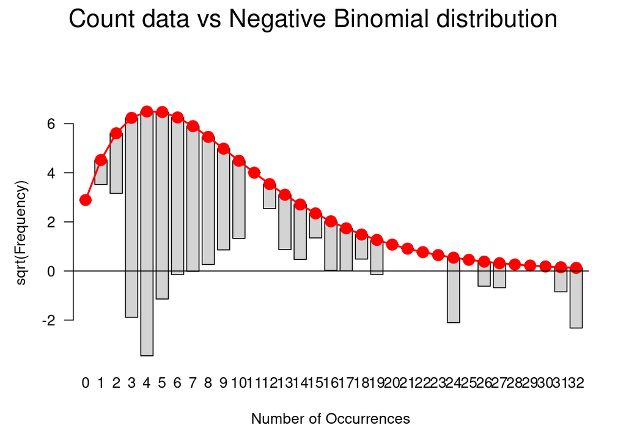

```r
plot(gf,main="Count data vs Negative Binomial distribution")
```

```r
gf <- goodfit(byblock$MaxPersistance, type= "poisson",method= "ML")
summary(gf)
```

```
##
##   Goodness-of-fit test for poisson distribution
##
##                       X^2 df      P(> X^2)
## Likelihood Ratio 756.7527 21 1.318867e-146
```

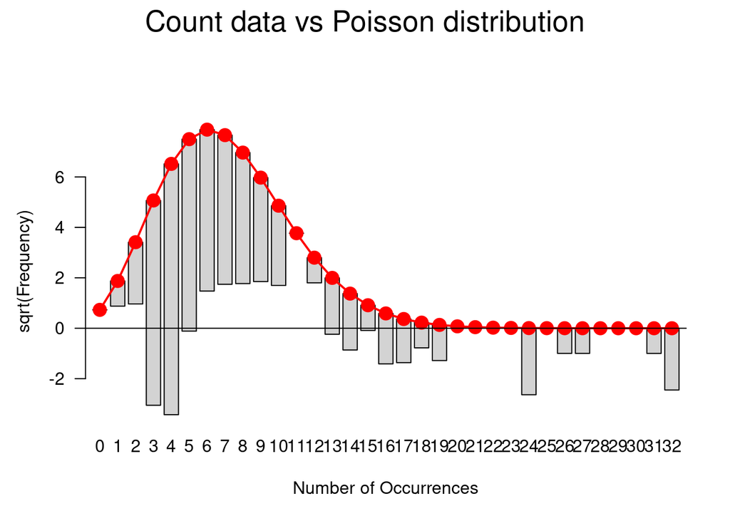

```r
plot(gf,main="Count data vs Poisson distribution")
```

# Group Differences in Response Times.

Then, we look at differences in RTs

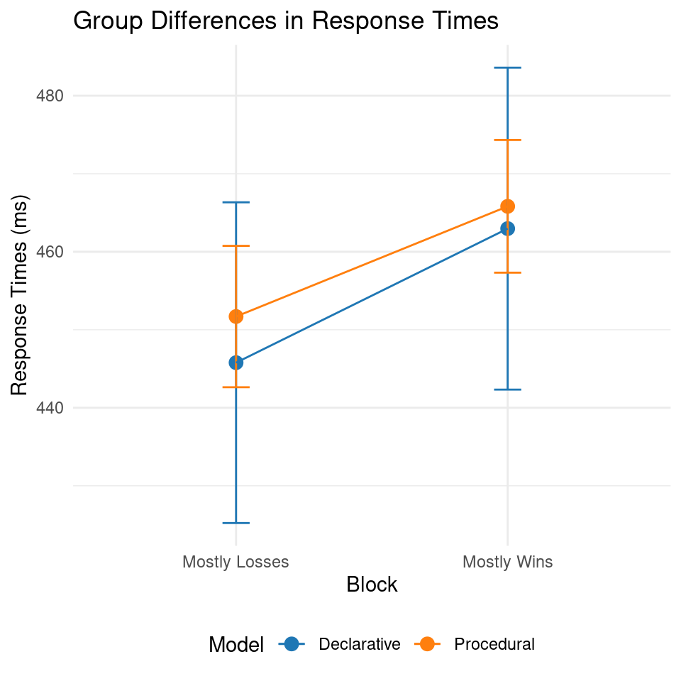

```r
ggplot(byblock, aes(x=Block, y=RT, col=Model, group=Model)) +
  stat_summary(geom="point", fun.data="mean_se", size=3) +
  stat_summary(geom="errorbar", fun.data = "mean_se", width=0.1) +
  stat_summary(geom="line", aes(group=Model), fun.data="mean_se") +
  ylab("Response Times (ms)") +
  ggtitle("Group Differences in Response Times") +
  scale_color_d3() +
  theme_minimal() +
  theme(legend.position = "bottom")
```

```r
ggsave("responsetimes.png", dpi=72)
```

This time, a linear mixed model does not reveal any effect, besides the effect of the win.

```r
mod3 <- glmer(log(RT) ~ Model * Block + (1|HCPID),
              family="Gamma",
              weights = abs(deltaLL),
              byblock)
tab_model(mod3)
```

|  | log(RT) |  |  |
| --- | --- | --- | --- |
| Predictors | Estimates | CI | p |
| (Intercept) | 1.18 | 1.18 – 1.18 | **<0.001** |
| Model [Procedural] | 1.00 | 1.00 – 1.00 | 0.527 |
| Block [Mostly Wins] | 1.00 | 1.00 – 1.00 | **0.002** |
| Model [Procedural] × Block [Mostly Wins] | 1.00 | 1.00 – 1.00 | 0.532 |
| Random Effects |  |  |  |
| σ<sup>2</sup> | 0.00 |  |  |
| τ<sub>00</sub> <sub>HCPID</sub> | 0.00 |  |  |
| ICC | 0.05 |  |  |
| N <sub>HCPID</sub> | 199 |  |  |
| Observations | 398 |  |  |
| Marginal R<sup>2</sup> / Conditional R<sup>2</sup> | 0.000 / 0.050 |  |  |

```r
model <- read_csv("../LL_model2.csv")
```

```
## ──────────────────────────────────────────────────────── Delimiter: "," chr
## (2): HCPID, best.model dbl (8): ...1, alpha, proc.temp, proc.LL, decay,
## decl.temp, decl.LL, diff.LL
```

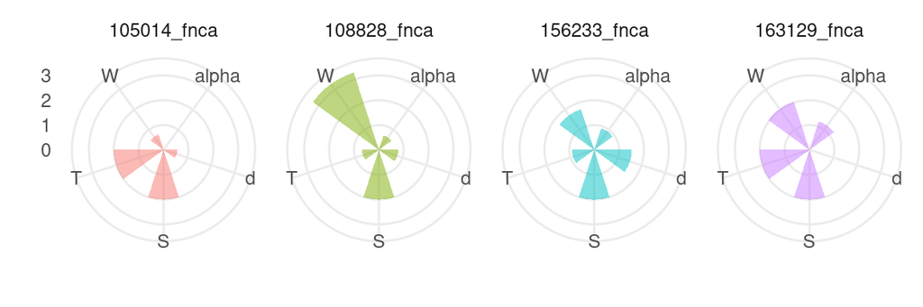

```r
model %>%pivot_longer(cols=c("alpha", "proc.temp", "decay", "decl.temp", "diff.LL"), names_to = "Parameter", values_to = "Values") -> lmodel

lmodel %>%
  mutate(Parameter = replace(Parameter, Parameter == "diff.LL", "W")) %>%
  mutate(Parameter = replace(Parameter, Parameter == "decay", "d")) %>%
  mutate(Parameter = replace(Parameter, Parameter == "proc.temp", "T")) %>%
  mutate(Parameter = replace(Parameter, Parameter == "decl.temp", "S")) -> lmodel

ggplot(filter(lmodel, HCPID %in% c("156233_fnca", "108828_fnca", "105014_fnca", "163129_fnca")),
       aes(x=Parameter, y = Values, fill=HCPID)) +
 geom_col(alpha=0.5, width=0.5) +
  #geom_line(aes(group=HCPID)) +
 coord_polar() +
  facet_wrap(~HCPID, ncol = 4) +
 theme_minimal() +
  xlab("") +
  ylab("") +
  theme(legend.position = "")
```